# Comparison by Cellchat

Zack

2026-06-14

```r
library(SpatialCellChat)
library(CellChat)
```

```r
library(patchwork)
library(ggplot2)
```

load calculated rds

```r
# Contact-dependent objects
chat_control_fvb <- readRDS(
  "C:/Bioinfo General/Spatial Analysis/Spatial analysis project/Output/Data/chat_control_fvb_contactRange20_final.rds"
)

chat_disease_fam <- readRDS(
  "C:/Bioinfo General/Spatial Analysis/Spatial analysis project/Output/Data/chat_disease_fam_contactRange20_final.rds"
)

# Secreted-signaling objects
chat_control_fvb_secreted <- readRDS(
  "C:/Bioinfo General/Spatial Analysis/Spatial analysis project/Output/Data/chat_control_fvb_secreted_range250_final.rds"
)

chat_disease_fam_secreted <- readRDS(
  "C:/Bioinfo General/Spatial Analysis/Spatial analysis project/Output/Data/chat_disease_fam_secreted_range250_final.rds"
)
```

Merge

```r
object.list.contact <- list(
  Control = chat_control_fvb,
  Disease = chat_disease_fam
)
object.list.secreted <- list(
  Control = chat_control_fvb_secreted,
  Disease = chat_disease_fam_secreted
)
cellchat.contact <- mergeSpatialCellChat(
  object.list.contact,
  add.names = names(object.list.contact),
  cell.prefix = TRUE
)
```

```
## The cell barcodes in merged 'meta' is  FVB_CD_aabaflhd-1 FVB_CD_aabbcpbj-1 FVB_CD_aadllhhb-1 FVB_CD_aaelliac-1 FVB_CD_aaimonce-1 FVB_CD_aakilfcg-1
## The cell barcodes in merged 'meta' is different from those in the used data matrix.
## We now simply assign the colnames in the data matrix to the rownames of merged 'meta'!
## Now the cell barcodes in merged 'meta' is  Control_FVB_CD_aabaflhd-1 Control_FVB_CD_aabbcpbj-1 Control_FVB_CD_aadllhhb-1 Control_FVB_CD_aaelliac-1 Control_FVB_CD_aaimonce-1 Control_FVB_CD_aakilfcg-1
## Merge the following slots:  'data.signaling','images','net', 'netP','meta', 'idents', 'var.features' , 'DB', and 'LR'.
```

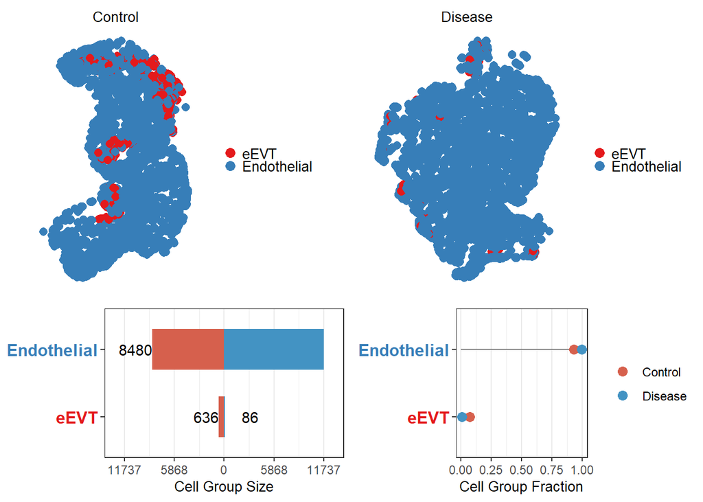

```r
cellchat.secreted <- mergeSpatialCellChat(
  object.list.secreted,
  add.names = names(object.list.secreted),
  cell.prefix = TRUE
)
```

```
## The cell barcodes in merged 'meta' is  FVB_CD_aabaflhd-1 FVB_CD_aabbcpbj-1 FVB_CD_aadllhhb-1 FVB_CD_aaelliac-1 FVB_CD_aaimonce-1 FVB_CD_aakilfcg-1
## The cell barcodes in merged 'meta' is different from those in the used data matrix.
## We now simply assign the colnames in the data matrix to the rownames of merged 'meta'!
## Now the cell barcodes in merged 'meta' is  Control_FVB_CD_aabaflhd-1 Control_FVB_CD_aabbcpbj-1 Control_FVB_CD_aadllhhb-1 Control_FVB_CD_aaelliac-1 Control_FVB_CD_aaimonce-1 Control_FVB_CD_aakilfcg-1
## Merge the following slots:  'data.signaling','images','net', 'netP','meta', 'idents', 'var.features' , 'DB', and 'LR'.
```

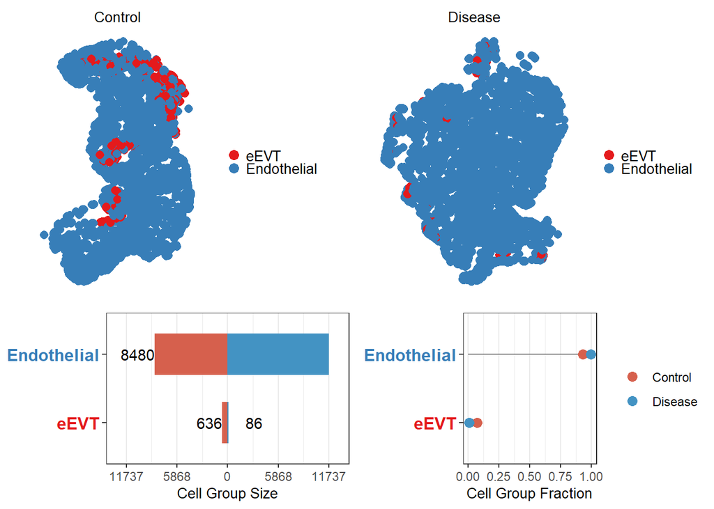

Part I: Identify altered interactions and cell populations

Compare the total number of interactions and interaction strength contact

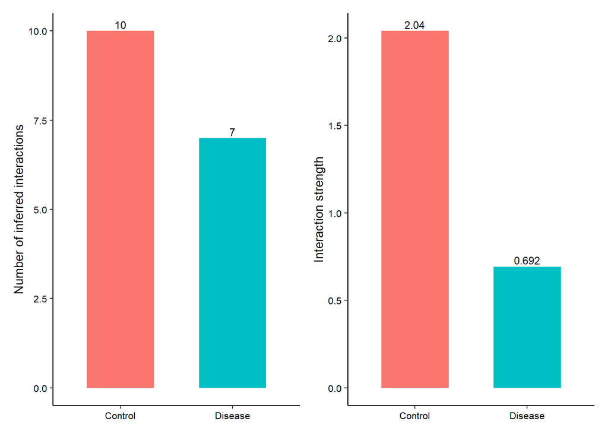

```r
gg1_contact <- compareInteractions(
  cellchat.contact,
  show.legend = FALSE,
  group = c(1, 2)
)

gg2_contact <- compareInteractions(
  cellchat.contact,
  show.legend = FALSE,
  group = c(1, 2),
  measure = "weight"
)

gg1_contact + gg2_contact
```

Secreted

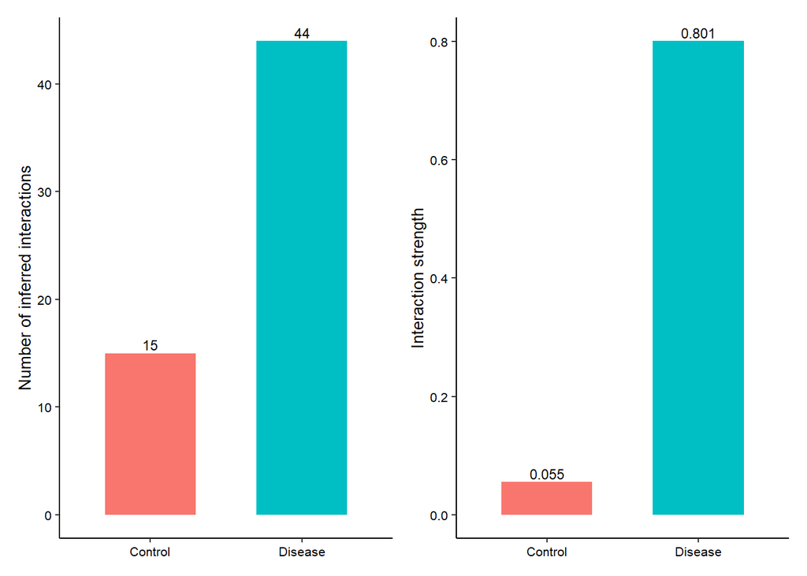

```r
gg1_secreted <- compareInteractions(
  cellchat.secreted,
  show.legend = FALSE,
  group = c(1, 2)
)

gg2_secreted <- compareInteractions(
  cellchat.secreted,
  show.legend = FALSE,
  group = c(1, 2),
  measure = "weight"
)

gg1_secreted + gg2_secreted
```

Differential Heatmap Contact

```r
gg1_contact <- netVisual_heatmap(cellchat.contact)
```

```
## Do heatmap based on a merged object
```

```r
#Weight takes account of LR-pair probability
gg2_contact <- netVisual_heatmap(cellchat.contact, measure = "weight")
```

```
## Do heatmap based on a merged object
```

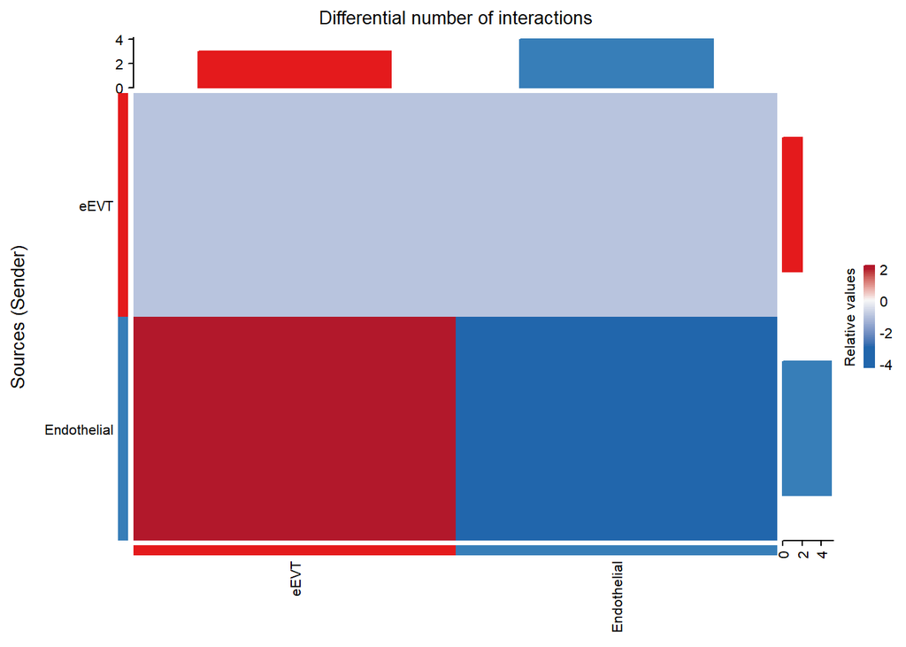

```r
gg1_contact
```

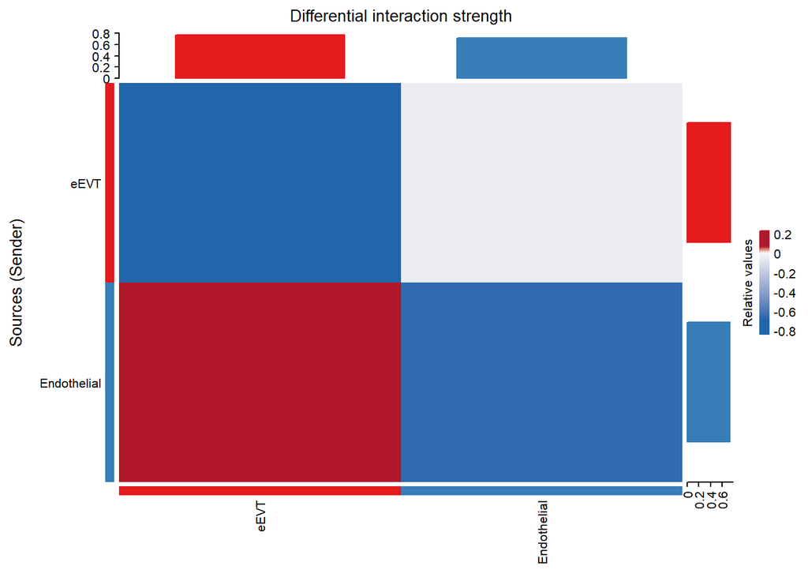

```r
gg2_contact
```

secreted

```r
gg1_secreted <- netVisual_heatmap(cellchat.secreted)
```

```
## Do heatmap based on a merged object
```

```r
gg2_secreted <- netVisual_heatmap(cellchat.secreted, measure = "weight")
```

```
## Do heatmap based on a merged object
```

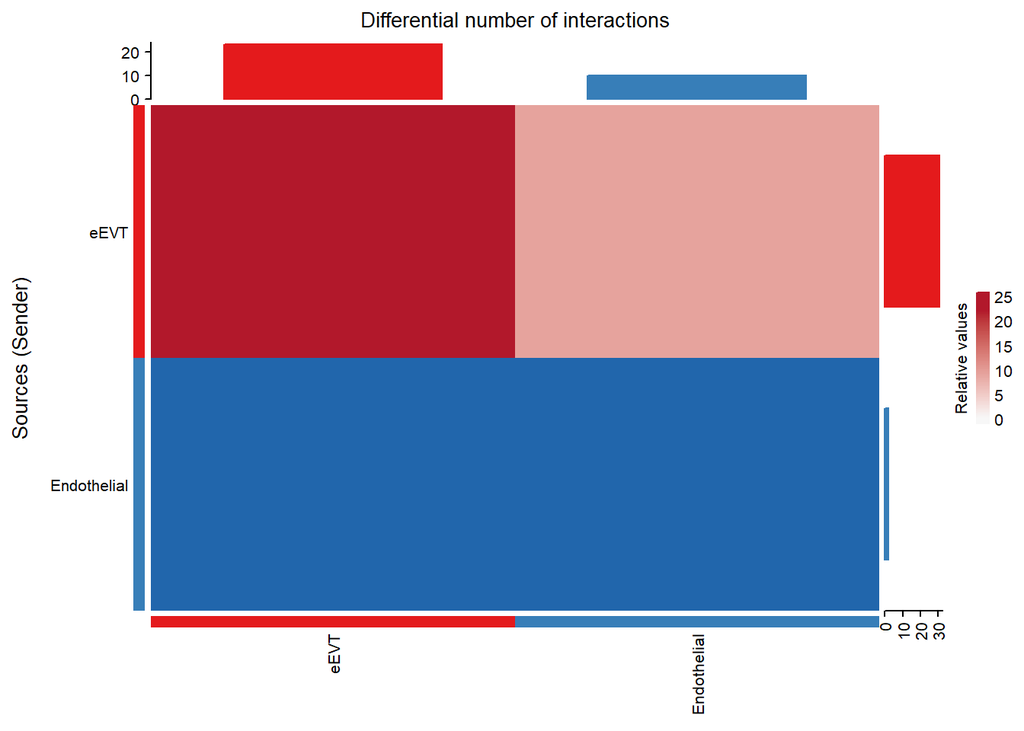

```r
gg1_secreted
```

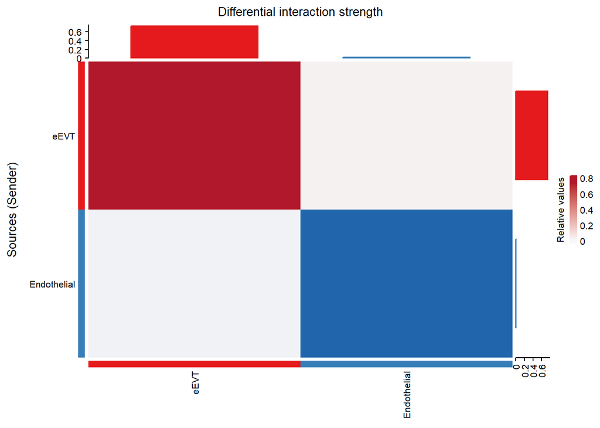

```r
gg2_secreted
```

Compare the major sources and targets in a 2D space (A) Identify cell populations with significant changes in sending or receiving signals Contact

```r
num.link.contact <- sapply(
  object.list.contact,
  function(x) {
    rowSums(x@net$count) +
      colSums(x@net$count) -
      diag(x@net$count)
  }
)

weight.MinMax.contact <- c(
  min(num.link.contact),
  max(num.link.contact)
)

gg.contact.role <- list()

for (i in seq_along(object.list.contact)) {
  gg.contact.role[[i]] <- SpatialCellChat::netAnalysis_signalingRole_scatter(
    object.list.contact[[i]],
    title = names(object.list.contact)[i],
    weight.MinMax = weight.MinMax.contact,
    x.measure = "outdeg",
    y.measure = "indeg"
  )
}
```

```
## Signaling role analysis on the aggregated cell-cell communication network from all signaling pathways
```

```
## Signaling role analysis on the aggregated cell-cell communication network from all signaling pathways
```

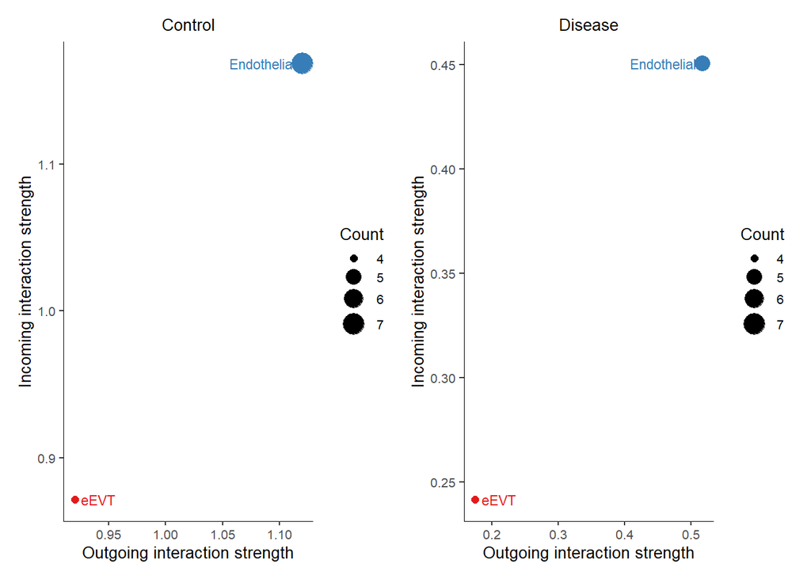

```r
patchwork::wrap_plots(plots = gg.contact.role)
```

Secreted

```r
num.link.secreted <- sapply(
  object.list.secreted,
  function(x) {
    rowSums(x@net$count) +
      colSums(x@net$count) -
      diag(x@net$count)
  }
)

weight.MinMax.secreted <- c(
  min(num.link.secreted),
  max(num.link.secreted)
)

gg.secreted.role <- list()

for (i in seq_along(object.list.secreted)) {
  gg.secreted.role[[i]] <- SpatialCellChat::netAnalysis_signalingRole_scatter(
    object.list.secreted[[i]],
    title = names(object.list.secreted)[i],
    weight.MinMax = weight.MinMax.secreted,
    x.measure = "outdeg",
    y.measure = "indeg"
  )
}
```

```
## Signaling role analysis on the aggregated cell-cell communication network from all signaling pathways
## Signaling role analysis on the aggregated cell-cell communication network from all signaling pathways
```

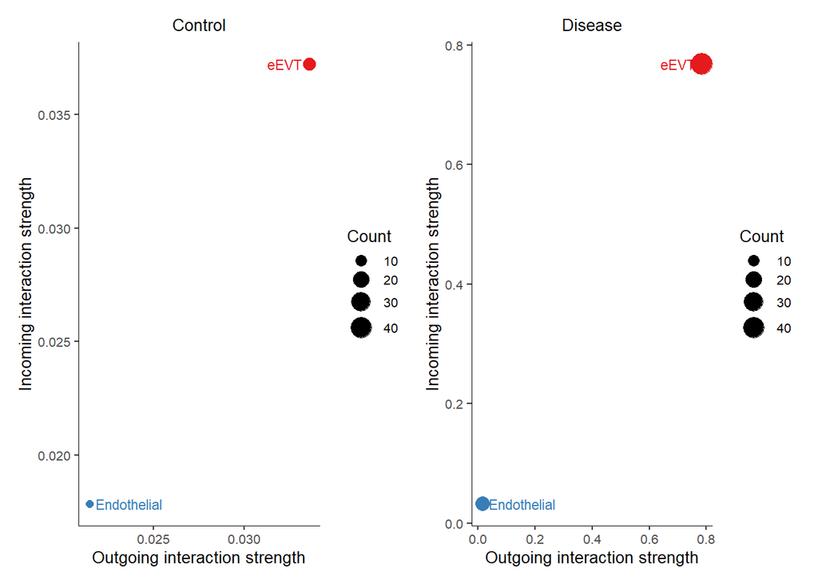

```r
patchwork::wrap_plots(plots = gg.secreted.role)
```

2. Identify the signaling changes of specific cell populations contact

```r
gg_eevt_contact <- SpatialCellChat::netAnalysis_signalingChanges_scatter(
  cellchat.contact,
  idents.use = "eEVT"
)
```

```
## Visualizing differential outgoing and incoming signaling changes from Control to Disease
```

```r
gg_endo_contact <- SpatialCellChat::netAnalysis_signalingChanges_scatter(
  cellchat.contact,
  idents.use = "Endothelial"
)
```

```
## Visualizing differential outgoing and incoming signaling changes from Control to Disease
```

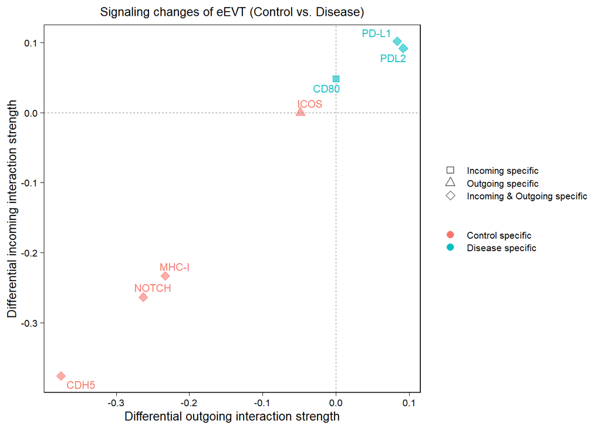

```r
gg_eevt_contact
```

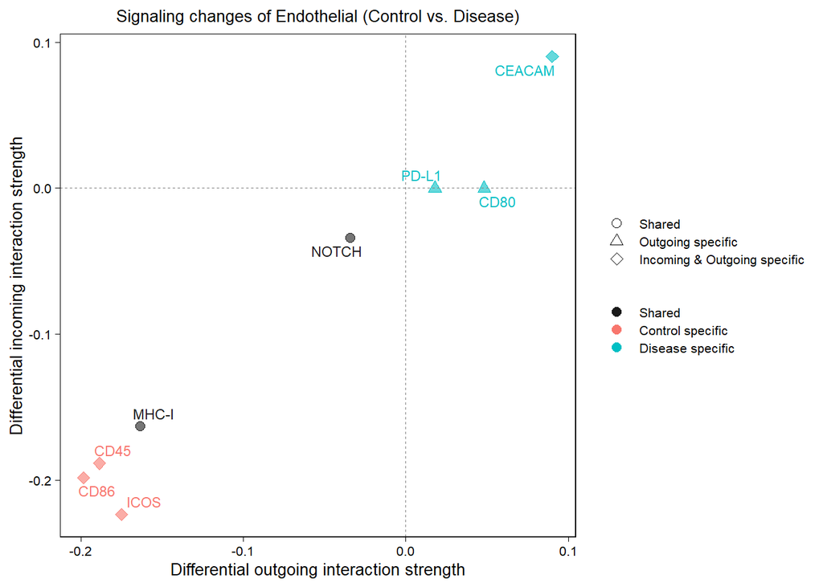

```r
gg_endo_contact
```

```r
gg2_eevt_secreted <- SpatialCellChat::netAnalysis_signalingChanges_scatter(
  cellchat.secreted,
  idents.use = "eEVT"
)
```

```
## Visualizing differential outgoing and incoming signaling changes from Control to Disease
```

```r
gg2_endo_secreted <- SpatialCellChat::netAnalysis_signalingChanges_scatter(
  cellchat.secreted,
  idents.use = "Endothelial"
)
```

```
## Visualizing differential outgoing and incoming signaling changes from Control to Disease
```

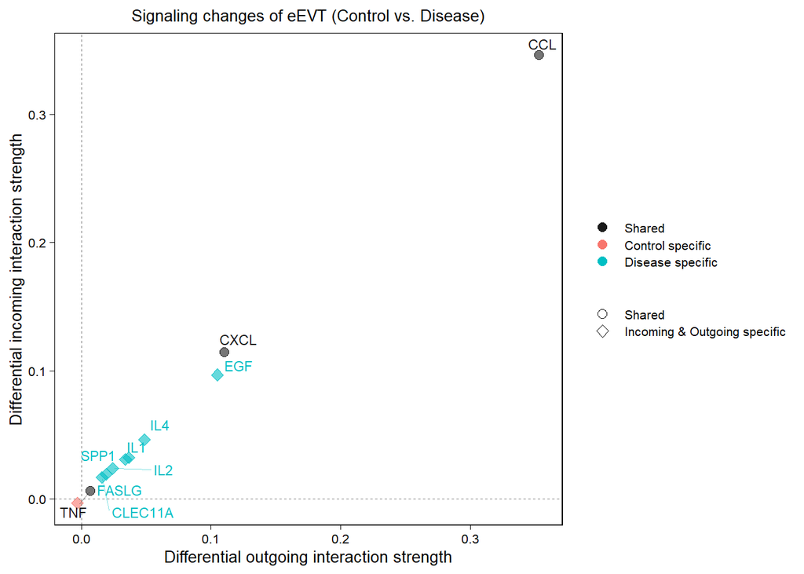

```r
gg2_eevt_secreted
```

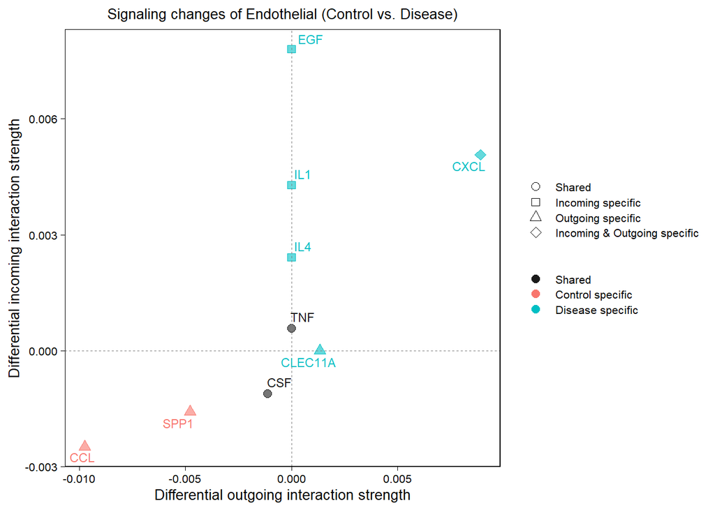

```r
gg2_endo_secreted
```

Part II: Identify altered signaling with distinct network architecture and interaction strength Identify signaling groups based on their functional similarity Similar sender and receiver-same cluster contact

```r
cellchat.contact <- SpatialCellChat::computeNetSimilarityPairwise(
  cellchat.contact,
  type = "functional"
)

cellchat.contact <- SpatialCellChat::netEmbedding(
  cellchat.contact,
  type = "functional"
)

cellchat.contact <- SpatialCellChat::netClustering(
  cellchat.contact,
  type = "functional"
)

SpatialCellChat::netVisual_embeddingPairwise(
  cellchat.contact,
  type = "functional",
  label.size = 3.5
)
```

```r
cellchat.contact <- readr::read_rds(
  "C:/Bioinfo General/Spatial Analysis/Spatial analysis project/Output/Data/cellchat_contact_functional_clustered.rds"
)

SpatialCellChat::netVisual_embeddingPairwise(
  cellchat.contact,
  type = "functional",
  label.size = 3.5
)
```

```
## 2D visualization of signaling networks from datasets 1 2
```

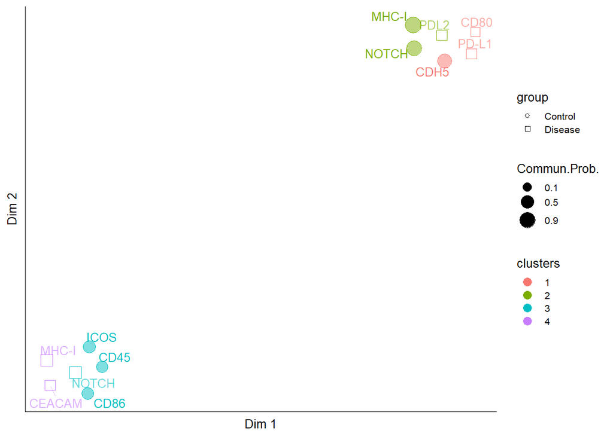

secreted

```r
cellchat.secreted <- SpatialCellChat::computeNetSimilarityPairwise(
  cellchat.secreted,
  type = "functional"
)

cellchat.secreted <- SpatialCellChat::netEmbedding(
  cellchat.secreted,
  type = "functional"
)

cellchat.secreted <- SpatialCellChat::netClustering(
  cellchat.secreted,
  type = "functional"
)

SpatialCellChat::netVisual_embeddingPairwise(
  cellchat.secreted,
  type = "functional",
  label.size = 3.5
)
```

```r
cellchat.secreted <- readr::read_rds(
  "C:/Bioinfo General/Spatial Analysis/Spatial analysis project/Output/Data/cellchat_secreted_functional_clustered.rds"
)

SpatialCellChat::netVisual_embeddingPairwise(
  cellchat.secreted,
  type = "functional",
  label.size = 3.5
)
```

```
## 2D visualization of signaling networks from datasets 1 2
```

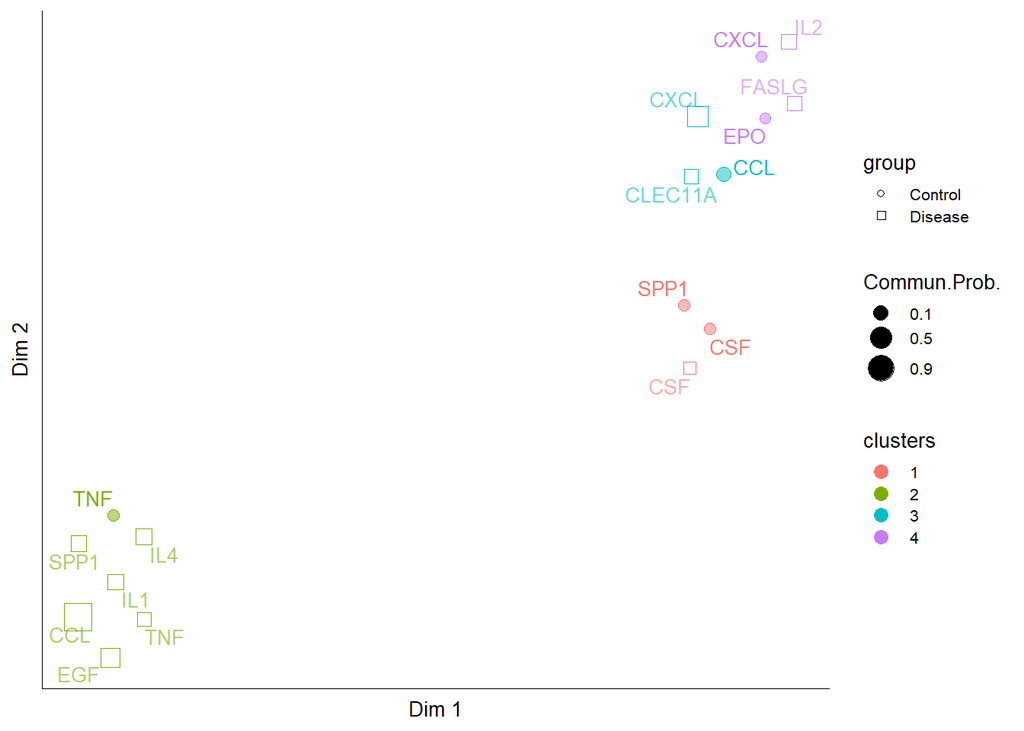

Identify signaling groups based on structure similarity contact

```r
# Allow larger objects to be handled by future/progressr during clustering
options(future.globals.maxSize = 2 * 1024^3)  # 2 GB
future::plan("sequential")

# Compute structural similarity between contact pathways based on overall network architecture
cellchat.contact <- SpatialCellChat::computeNetSimilarityPairwise(
  cellchat.contact,
  type = "structural"
)

cellchat.contact <- SpatialCellChat::netEmbedding(
  cellchat.contact,
  type = "structural"
)

cellchat.contact <- SpatialCellChat::netClustering(
  cellchat.contact,
  type = "structural"
)

SpatialCellChat::netVisual_embeddingPairwise(
  cellchat.contact,
  type = "structural",
  label.size = 3.5
)

SpatialCellChat::netVisual_embeddingPairwiseZoomIn(
  cellchat.contact,
  type = "structural",
  nCol = 2
)
```

```r
# Load precomputed contact structural similarity embedding and clustering result
cellchat.contact <- readr::read_rds(
  "C:/Bioinfo General/Spatial Analysis/Spatial analysis project/Output/Data/cellchat_contact_structural_clustered.rds"
)

SpatialCellChat::netVisual_embeddingPairwise(
  cellchat.contact,
  type = "structural",
  label.size = 3.5
)
```

```
## 2D visualization of signaling networks from datasets 1 2
```

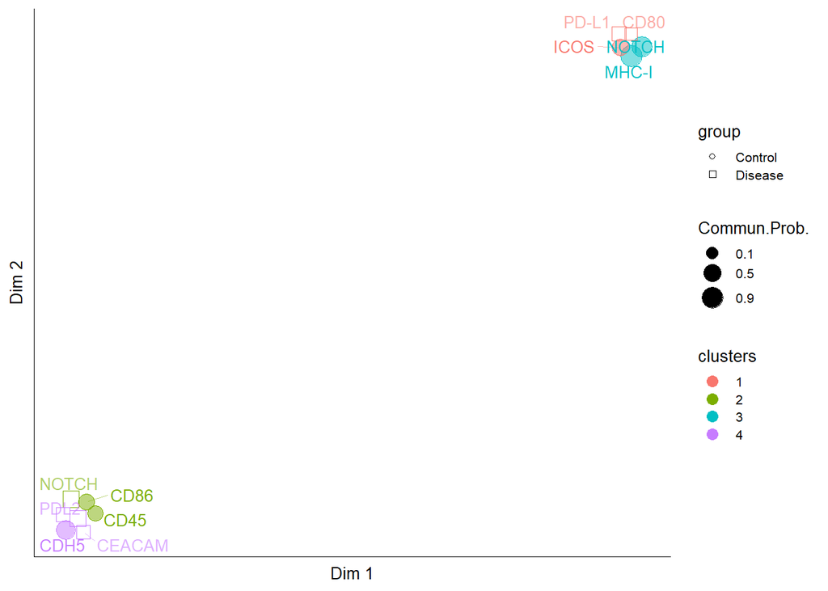

```r
SpatialCellChat::netVisual_embeddingPairwiseZoomIn(
  cellchat.contact,
  type = "structural",
  nCol = 2
)
```

```
## 2D visualization of signaling networks from datasets 1 2
```

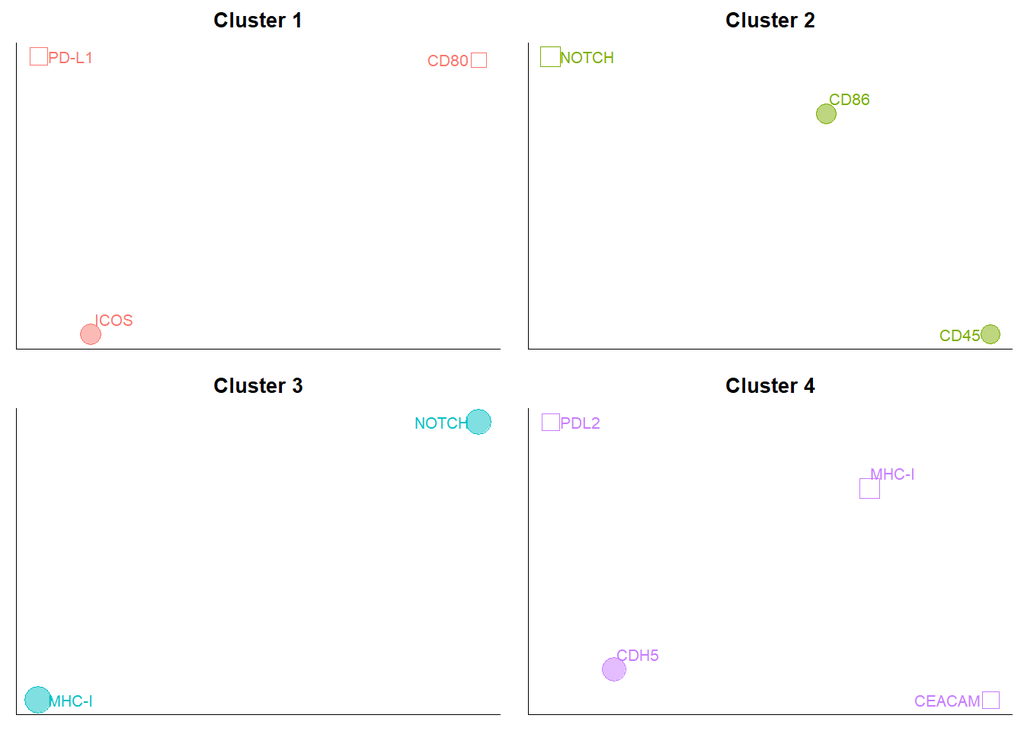

secreted

```r
cellchat.secreted <- SpatialCellChat::computeNetSimilarityPairwise(
  cellchat.secreted,
  type = "structural"
)

cellchat.secreted <- SpatialCellChat::netEmbedding(
  cellchat.secreted,
  type = "structural"
)

cellchat.secreted <- SpatialCellChat::netClustering(
  cellchat.secreted,
  type = "structural"
)

SpatialCellChat::netVisual_embeddingPairwise(
  cellchat.secreted,
  type = "structural",
  label.size = 3.5
)

SpatialCellChat::netVisual_embeddingPairwiseZoomIn(
  cellchat.secreted,
  type = "structural",
  nCol = 2
)
```

```r
cellchat.secreted <- readr::read_rds(
  "C:/Bioinfo General/Spatial Analysis/Spatial analysis project/Output/Data/cellchat_secreted_structural_clustered.rds"
)

SpatialCellChat::netVisual_embeddingPairwise(
  cellchat.secreted,
  type = "structural",
  label.size = 3.5
)
```

```
## 2D visualization of signaling networks from datasets 1 2
```

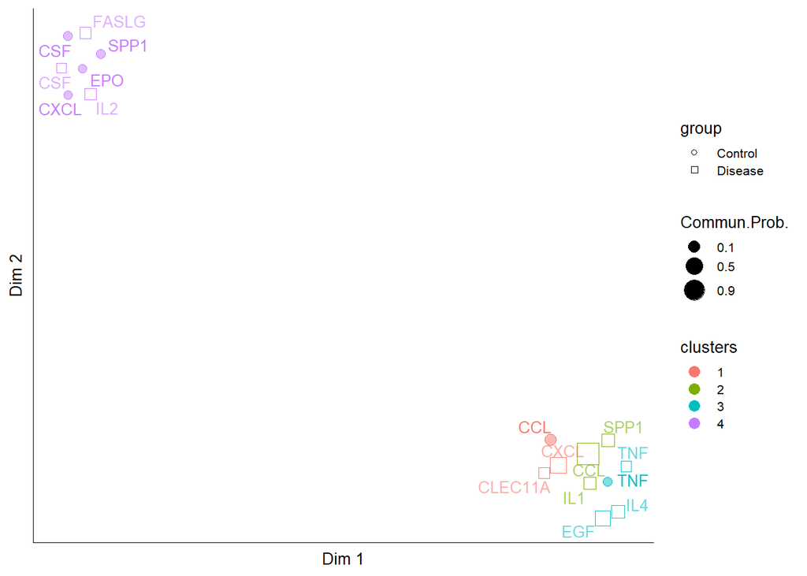

```r
SpatialCellChat::netVisual_embeddingPairwiseZoomIn(
  cellchat.secreted,
  type = "structural",
  nCol = 2
)
```

```
## 2D visualization of signaling networks from datasets 1 2
```

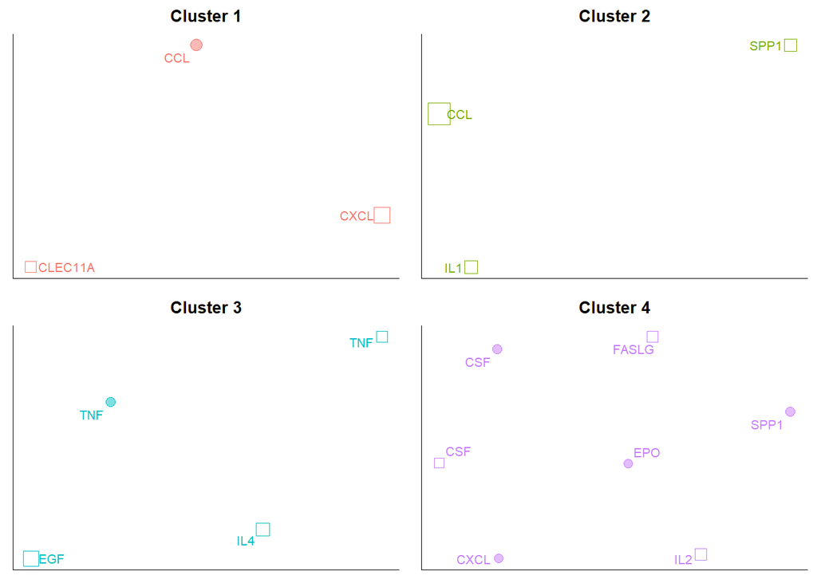

Compute and visualize the pathway distance in the learned joint manifold contact

```r
CellChat::rankSimilarity(
  cellchat.contact,
  type = "functional"
)
```

[output not shown]

secreted

```r
CellChat::rankSimilarity(
  cellchat.secreted,
  type = "functional"
)
```

[output not shown]

Identify altered signaling with distinct interaction strength (A) Compare the overall information flow of each signaling pathway or ligand-receptor pair contact

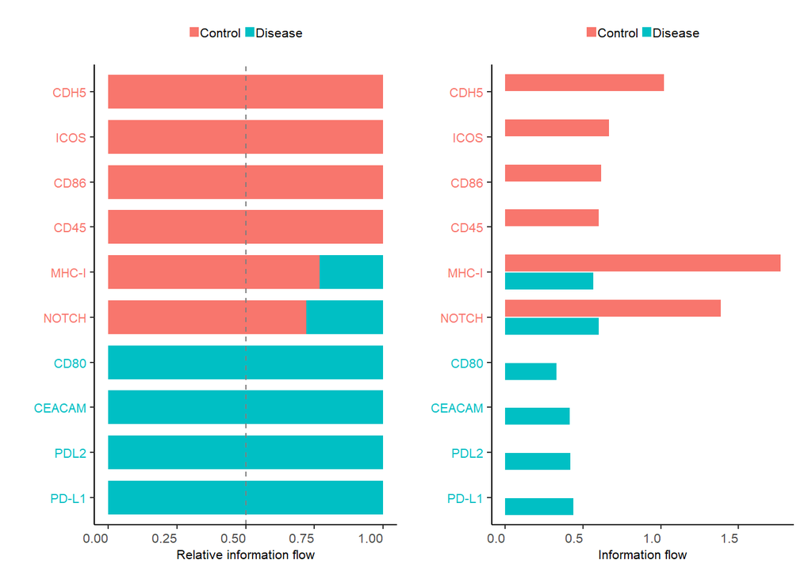

```r
gg1_contact_ranknet <- SpatialCellChat::rankNet(
  cellchat.contact,
  mode = "comparison",
  measure = "weight",
  sources.use = NULL,
  targets.use = NULL,
  stacked = TRUE,
  do.stat = TRUE
)

gg2_contact_ranknet <- SpatialCellChat::rankNet(
  cellchat.contact,
  mode = "comparison",
  measure = "weight",
  sources.use = NULL,
  targets.use = NULL,
  stacked = FALSE,
  do.stat = TRUE
)

gg1_contact_ranknet + gg2_contact_ranknet
```

secreted

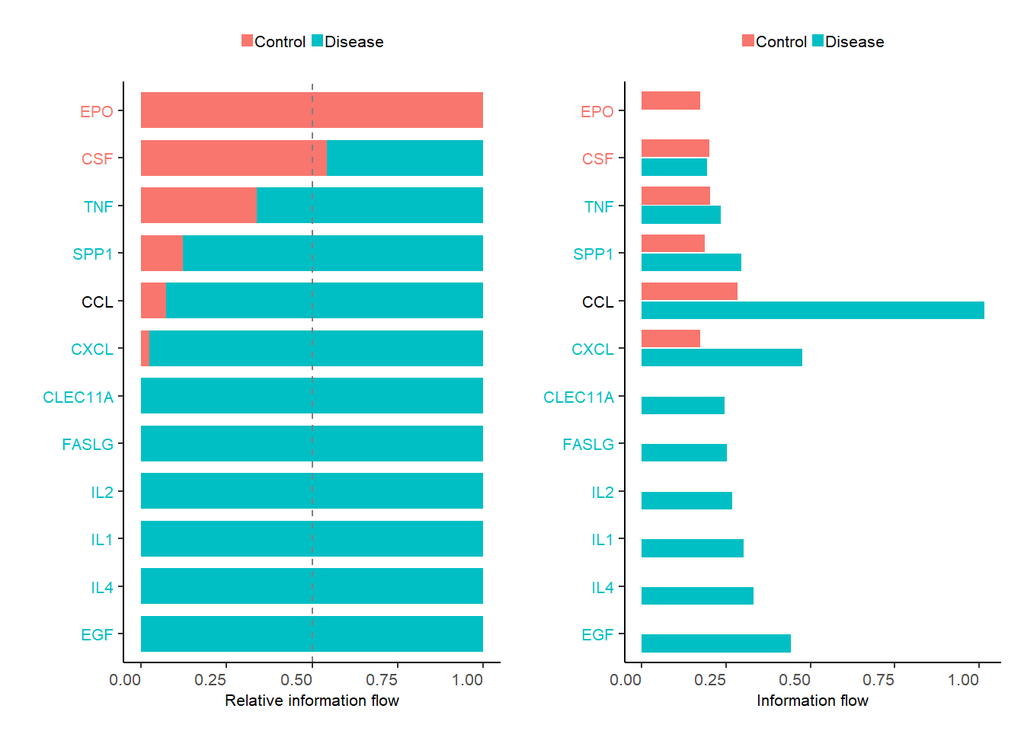

```r
gg1_secreted_ranknet <- SpatialCellChat::rankNet(
  cellchat.secreted,
  mode = "comparison",
  measure = "weight",
  sources.use = NULL,
  targets.use = NULL,
  stacked = TRUE,
  do.stat = TRUE
)

gg2_secreted_ranknet <- SpatialCellChat::rankNet(
  cellchat.secreted,
  mode = "comparison",
  measure = "weight",
  sources.use = NULL,
  targets.use = NULL,
  stacked = FALSE,
  do.stat = TRUE
)

gg1_secreted_ranknet + gg2_secreted_ranknet
```

(B) Compare outgoing (or incoming) signaling patterns associated with each cell population contact

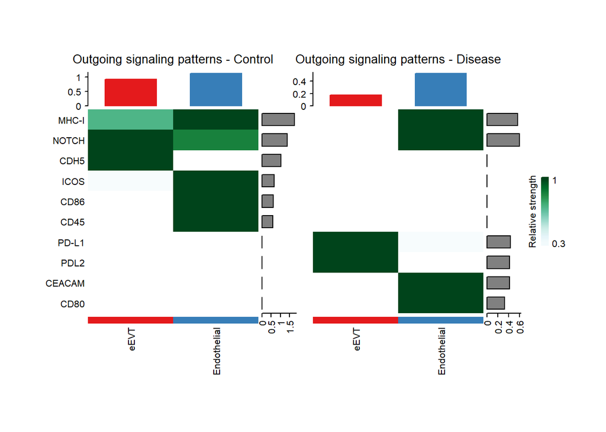

```r
library(ComplexHeatmap)
library(grid)

# Use the first two datasets, following the CellChat tutorial
i <- 1
j <- 2

# Combine all identified signaling pathways from the two datasets
pathway.union.contact <- union(
  object.list.contact[[i]]@netP$pathways,
  object.list.contact[[j]]@netP$pathways
)

# Outgoing signaling

ht_contact_out_1 <- SpatialCellChat::netAnalysis_signalingRole_heatmap(
  object.list.contact[[i]],
  pattern = "outgoing",
  signaling = pathway.union.contact,
  title = names(object.list.contact)[i],
  width = 5,
  height = 6
)

ht_contact_out_2 <- SpatialCellChat::netAnalysis_signalingRole_heatmap(
  object.list.contact[[j]],
  pattern = "outgoing",
  signaling = pathway.union.contact,
  title = names(object.list.contact)[j],
  width = 5,
  height = 6
)

ComplexHeatmap::draw(
  ht_contact_out_1 + ht_contact_out_2,
  ht_gap = grid::unit(0.5, "cm")
)
```

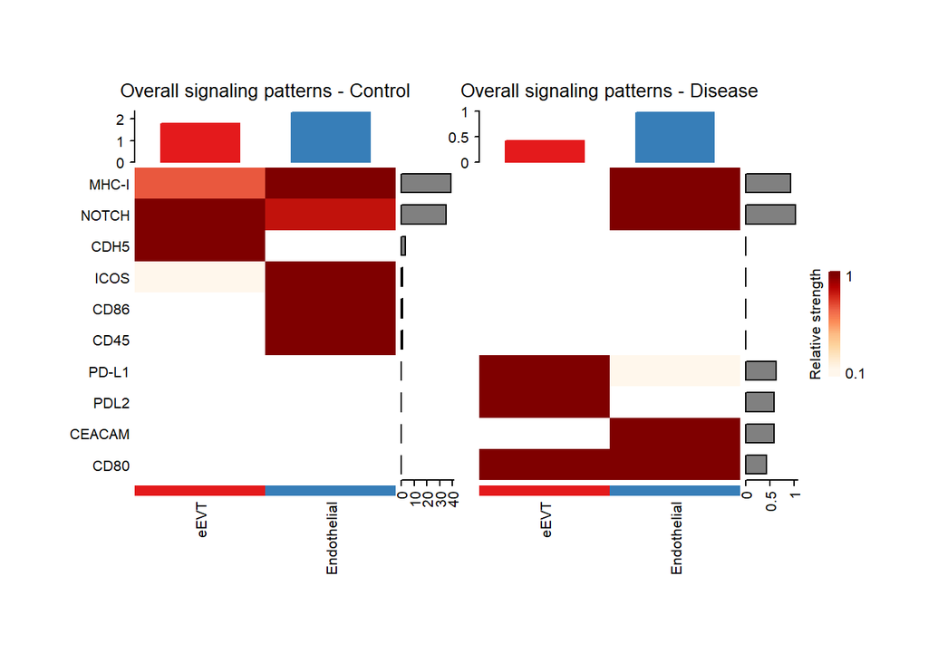

```r
# Incoming signaling
#There is a lack of significant incoming signal in disease so heatmap cannot be drawn

# Overall signaling
# outgoing + incoming

ht_contact_all_1 <- SpatialCellChat::netAnalysis_signalingRole_heatmap(
  object.list.contact[[i]],
  pattern = "all",
  signaling = pathway.union.contact,
  title = names(object.list.contact)[i],
  width = 5,
  height = 6,
  color.heatmap = "OrRd"
)

ht_contact_all_2 <- SpatialCellChat::netAnalysis_signalingRole_heatmap(
  object.list.contact[[j]],
  pattern = "all",
  signaling = pathway.union.contact,
  title = names(object.list.contact)[j],
  width = 5,
  height = 6,
  color.heatmap = "OrRd"
)

ComplexHeatmap::draw(
  ht_contact_all_1 + ht_contact_all_2,
  ht_gap = grid::unit(0.5, "cm")
)
```

secreted

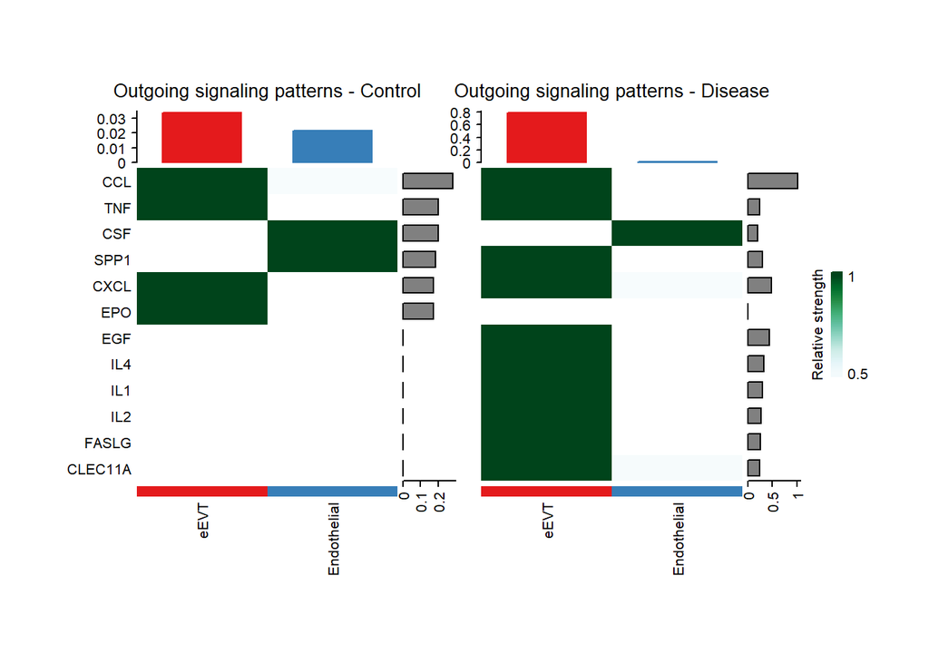

```r
library(ComplexHeatmap)
library(grid)

i <- 1
j <- 2

pathway.union.secreted <- union(
  object.list.secreted[[i]]@netP$pathways,
  object.list.secreted[[j]]@netP$pathways
)

# Outgoing signaling

ht_secreted_out_1 <- SpatialCellChat::netAnalysis_signalingRole_heatmap(
  object.list.secreted[[i]],
  pattern = "outgoing",
  signaling = pathway.union.secreted,
  title = names(object.list.secreted)[i],
  width = 5,
  height = 6
)

ht_secreted_out_2 <- SpatialCellChat::netAnalysis_signalingRole_heatmap(
  object.list.secreted[[j]],
  pattern = "outgoing",
  signaling = pathway.union.secreted,
  title = names(object.list.secreted)[j],
  width = 5,
  height = 6
)

ComplexHeatmap::draw(
  ht_secreted_out_1 + ht_secreted_out_2,
  ht_gap = grid::unit(0.5, "cm")
)
```

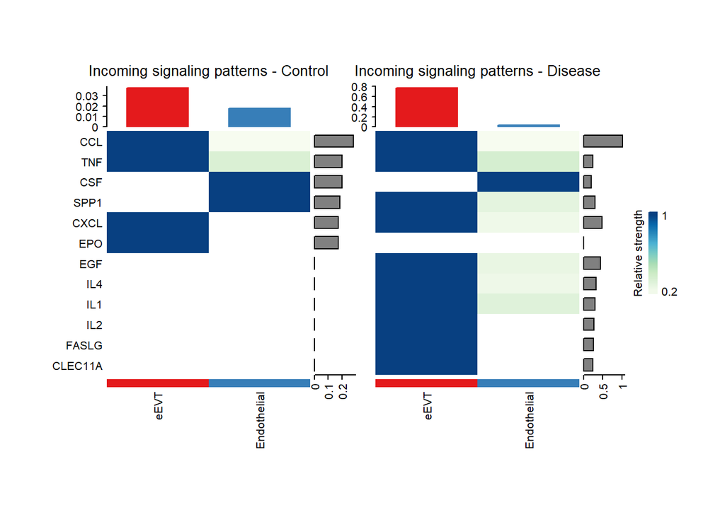

```r
# Incoming signaling

ht_secreted_in_1 <- SpatialCellChat::netAnalysis_signalingRole_heatmap(
  object.list.secreted[[i]],
  pattern = "incoming",
  signaling = pathway.union.secreted,
  title = names(object.list.secreted)[i],
  width = 5,
  height = 6,
  color.heatmap = "GnBu"
)

ht_secreted_in_2 <- SpatialCellChat::netAnalysis_signalingRole_heatmap(
  object.list.secreted[[j]],
  pattern = "incoming",
  signaling = pathway.union.secreted,
  title = names(object.list.secreted)[j],
  width = 5,
  height = 6,
  color.heatmap = "GnBu"
)

ComplexHeatmap::draw(
  ht_secreted_in_1 + ht_secreted_in_2,
  ht_gap = grid::unit(0.5, "cm")
)
```

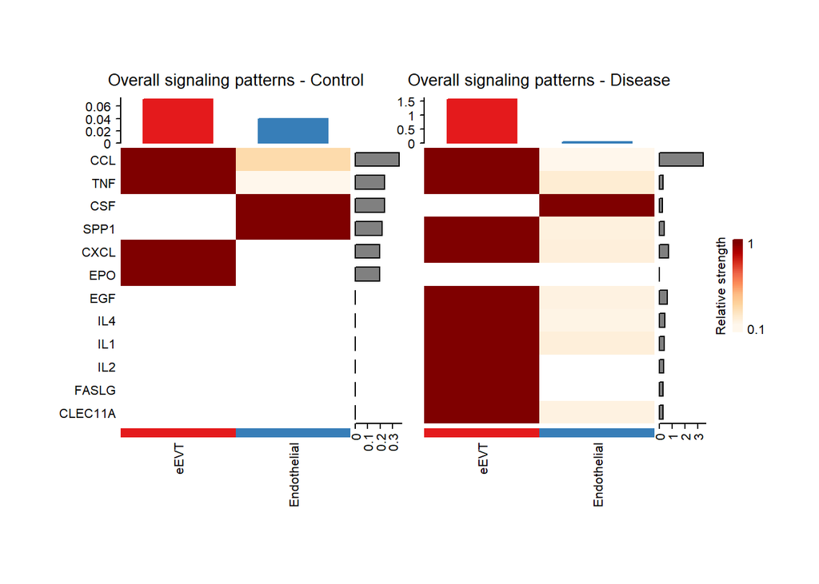

```r
# Overall signaling
# outgoing + incoming

ht_secreted_all_1 <- SpatialCellChat::netAnalysis_signalingRole_heatmap(
  object.list.secreted[[i]],
  pattern = "all",
  signaling = pathway.union.secreted,
  title = names(object.list.secreted)[i],
  width = 5,
  height = 6,
  color.heatmap = "OrRd"
)

ht_secreted_all_2 <- SpatialCellChat::netAnalysis_signalingRole_heatmap(
  object.list.secreted[[j]],
  pattern = "all",
  signaling = pathway.union.secreted,
  title = names(object.list.secreted)[j],
  width = 5,
  height = 6,
  color.heatmap = "OrRd"
)

ComplexHeatmap::draw(
  ht_secreted_all_1 + ht_secreted_all_2,
  ht_gap = grid::unit(0.5, "cm")
)
```

Part III: Identify the up-gulated and down-regulated signaling ligand-receptor pairs Identify dysfunctional signaling by comparing the communication probabities contact

```r
# Show contact LR interactions that are stronger in Disease than Control
gg1 <- CellChat::netVisual_bubble(
  cellchat.contact,
  sources.use = c("eEVT", "Endothelial"),
  targets.use = c("eEVT", "Endothelial"),
  comparison = c(1, 2),
  max.dataset = 2,
  title.name = "Increased signaling in Disease",
  angle.x = 45,
  remove.isolate = TRUE
)
```

```
## Comparing communications on a merged object
```

```r
# Show contact LR interactions that are stronger in Control, i.e. decreased in Disease
gg2 <- CellChat::netVisual_bubble(
  cellchat.contact,
  sources.use = c("eEVT", "Endothelial"),
  targets.use = c("eEVT", "Endothelial"),
  comparison = c(1, 2),
  max.dataset = 1,
  title.name = "Decreased signaling in Disease",
  angle.x = 45,
  remove.isolate = TRUE
)
```

```
## Comparing communications on a merged object
```

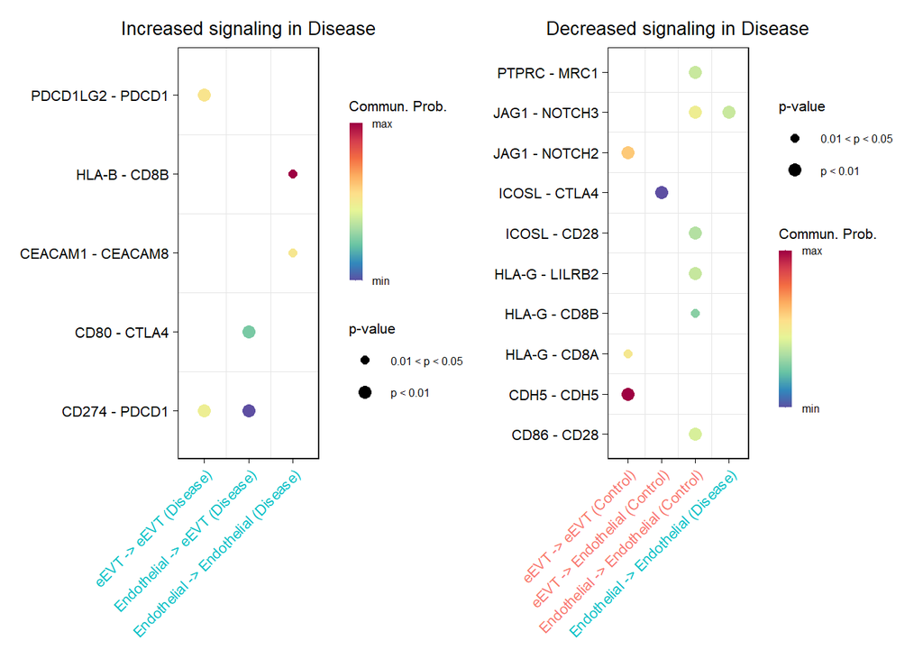

```r
gg1 + gg2
```

secreted

```r
# Show contact LR interactions that are stronger in Disease than Control
gg1 <- CellChat::netVisual_bubble(
  cellchat.secreted,
  sources.use = c("eEVT", "Endothelial"),
  targets.use = c("eEVT", "Endothelial"),
  comparison = c(1, 2),
  max.dataset = 2,
  title.name = "Increased signaling in Disease",
  angle.x = 45,
  remove.isolate = TRUE
)
```

```
## Comparing communications on a merged object
```

```r
# Show contact LR interactions that are stronger in Control, i.e. decreased in Disease
gg2 <- CellChat::netVisual_bubble(
  cellchat.secreted,
  sources.use = c("eEVT", "Endothelial"),
  targets.use = c("eEVT", "Endothelial"),
  comparison = c(1, 2),
  max.dataset = 1,
  title.name = "Decreased signaling in Disease",
  angle.x = 45,
  remove.isolate = TRUE
)
```

```
## Comparing communications on a merged object
```

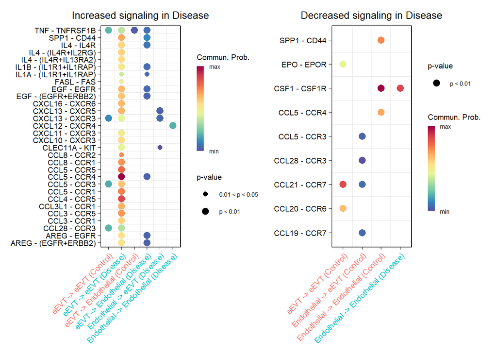

```r
gg1 + gg2
```

Identify dysfunctional signaling by using differential expression analysis contact

```r
pos.dataset <- "Disease"
features.name <- paste0(pos.dataset, ".merged")

cellchat.contact <- CellChat::identifyOverExpressedGenes(
  cellchat.contact,
  group.dataset = "datasets",
  pos.dataset = pos.dataset,
  features.name = features.name,
  only.pos = FALSE,
  thresh.pc = 0.1,
  thresh.fc = 0.05,
  thresh.p = 0.05
)
```

```
## Use the joint cell labels from the merged CellChat object
```

```r
# map DEA results onto inferred communications
net.contact <- CellChat::netMappingDEG(
  cellchat.contact,
  features.name = features.name
)

net.up.contact <- CellChat::subsetCommunication(
  cellchat.contact,
  net = net.contact,
  datasets = "Disease",
  ligand.logFC = 0.05,
  receptor.logFC = NULL
)

net.down.contact <- CellChat::subsetCommunication(
  cellchat.contact,
  net = net.contact,
  datasets = "Control",
  ligand.logFC = -0.05,
  receptor.logFC = NULL
)

gene.up.contact <- CellChat::extractGeneSubsetFromPair(
  net.up.contact,
  cellchat.contact
)

gene.down.contact <- CellChat::extractGeneSubsetFromPair(
  net.down.contact,
  cellchat.contact
)
```

secreted

```r
pos.dataset <- "Disease"
features.name <- paste0(pos.dataset, ".merged")

# perform differential expression analysis
cellchat.secreted <- CellChat::identifyOverExpressedGenes(
  cellchat.secreted,
  group.dataset = "datasets",
  pos.dataset = pos.dataset,
  features.name = features.name,
  only.pos = FALSE,
  thresh.pc = 0.1,
  thresh.fc = 0.05,
  thresh.p = 0.05
)
```

```
## Use the joint cell labels from the merged CellChat object
```

```r
# map DEG results onto inferred communications
net.secreted <- CellChat::netMappingDEG(
  cellchat.secreted,
  features.name = features.name
)

# LR pairs with upregulated ligands in Disease
net.up.secreted <- CellChat::subsetCommunication(
  cellchat.secreted,
  net = net.secreted,
  datasets = "Disease",
  ligand.logFC = 0.05,
  receptor.logFC = NULL
)

# LR pairs relatively downregulated in Disease
# i.e. higher in Control
net.down.secreted <- CellChat::subsetCommunication(
  cellchat.secreted,
  net = net.secreted,
  datasets = "Control",
  ligand.logFC = -0.05,
  receptor.logFC = NULL
)

# deconvolute signaling genes from LR pairs
gene.up.secreted <- CellChat::extractGeneSubsetFromPair(
  net.up.secreted,
  cellchat.secreted
)

gene.down.secreted <- CellChat::extractGeneSubsetFromPair(
  net.down.secreted,
  cellchat.secreted
)
```

Visualize the identified up-regulated and down-regulated signaling ligand-receptor pairs (A) Bubble plot contact

```r
pairLR.use.up.contact <- net.up.contact[, "interaction_name", drop = FALSE]

gg1_contact <- CellChat::netVisual_bubble(
  cellchat.contact,
  pairLR.use = pairLR.use.up.contact,
  sources.use = c("eEVT", "Endothelial"),
  targets.use = c("eEVT", "Endothelial"),
  comparison = c(1, 2),
  angle.x = 90,
  remove.isolate = TRUE,
  title.name = "Contact: up-regulated signaling in Disease"
)
```

```
## Comparing communications on a merged object
```

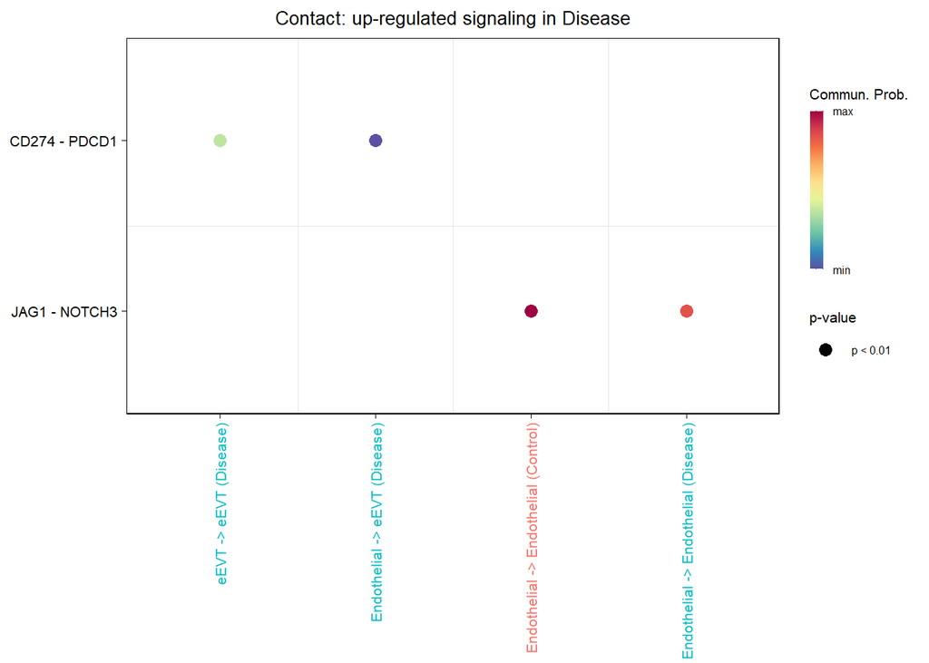

```r
pairLR.use.down.contact <- net.down.contact[, "interaction_name", drop = FALSE]

#No significant signaling interactions are inferred based on the input
# gg2_contact <- CellChat::netVisual_bubble(
#   cellchat.contact,
#   pairLR.use = pairLR.use.down.contact,
#   sources.use = c("eEVT", "Endothelial"),
#   targets.use = c("eEVT", "Endothelial"),
#   comparison = c(1, 2),
#   angle.x = 90,
#   remove.isolate = TRUE,
#   title.name = "Contact: down-regulated signaling in Disease"
# )

gg1_contact
```

secreted

```r
pairLR.use.up <- net.up.secreted[, "interaction_name", drop = FALSE]

gg1 <-  CellChat::netVisual_bubble(
  cellchat.secreted,
  pairLR.use = pairLR.use.up,
  sources.use = c("eEVT", "Endothelial"),
  targets.use = c("eEVT", "Endothelial"),
  comparison = c(1, 2),
  angle.x = 90,
  remove.isolate = TRUE,
  title.name = "Up-regulated signaling in Disease"
)
```

```
## Comparing communications on a merged object
```

```r
pairLR.use.down <- net.down.secreted[, "interaction_name", drop = FALSE]

gg2 <-  CellChat::netVisual_bubble(
  cellchat.secreted,
  pairLR.use = pairLR.use.down,
  sources.use = c("eEVT", "Endothelial"),
  targets.use = c("eEVT", "Endothelial"),
  comparison = c(1, 2),
  angle.x = 90,
  remove.isolate = TRUE,
  title.name = "Down-regulated signaling in Disease"
)
```

```
## Comparing communications on a merged object
```

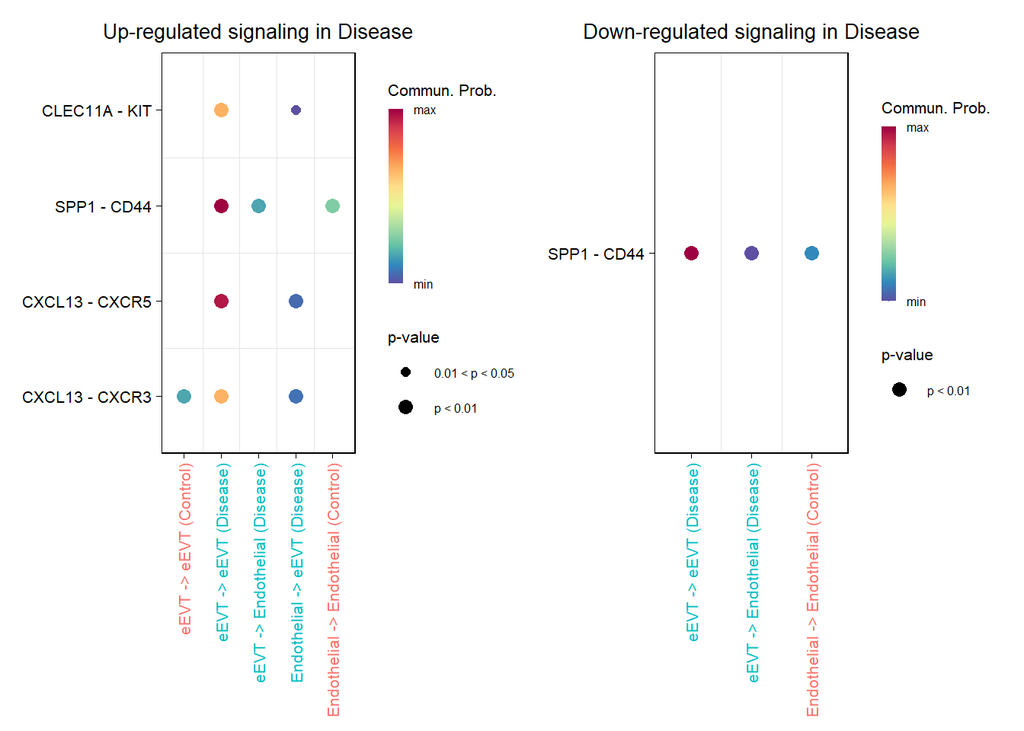

```r
gg1 + gg2
```

Part V: Compare the signaling gene expression distribution between different datasets

```r
# make sure dataset order is Control -> Disease
cellchat.contact@meta$datasets <- factor(
  cellchat.contact@meta$datasets,
  levels = c("Control", "Disease")
)

# Violin plot for NOTCH signaling genes
p_notch_expr <- CellChat::plotGeneExpression(
  cellchat.contact,
  signaling = "NOTCH",
  split.by = "datasets",
  colors.ggplot = TRUE,
  type = "violin"
)
```

```
## The default behaviour of split.by has changed.
## Separate violin plots are now plotted side-by-side.
## To restore the old behaviour of a single split violin,
## set split.plot = TRUE.
##
## This message will be shown once per session.
```

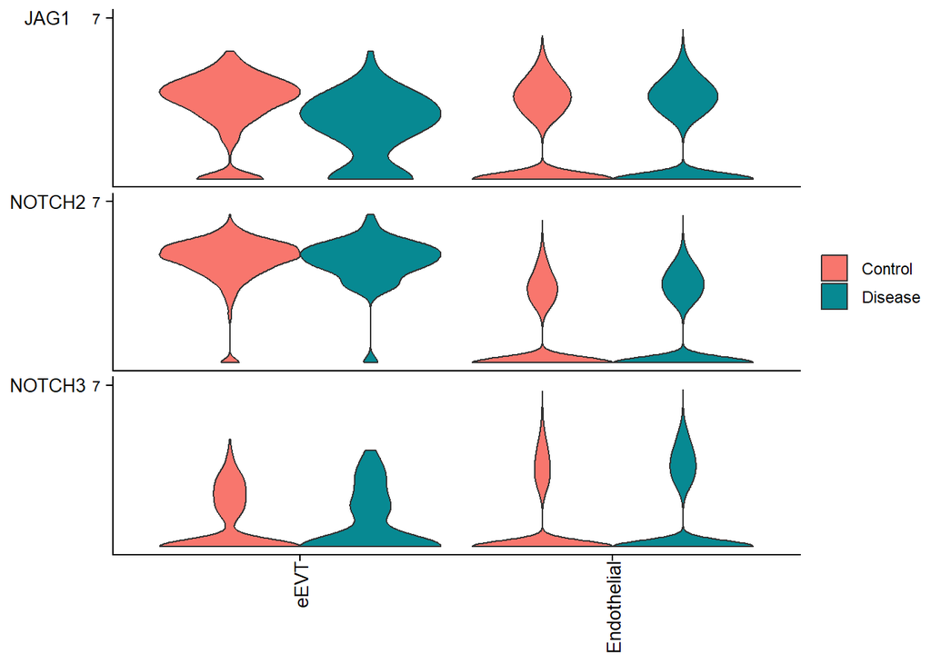

```r
p_notch_expr
```

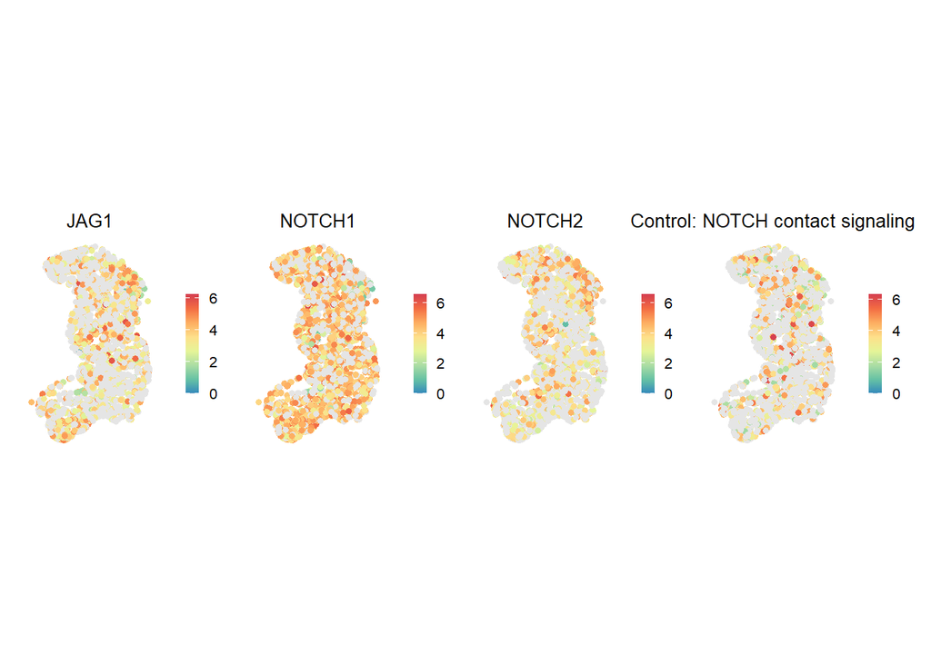

```r
pathway.show <- "NOTCH"

# Control
p_notch_control <- SpatialCellChat::spatialFeaturePlot(
  object.list.contact[[1]],
  signaling = pathway.show,
  do.group = FALSE,
  do.binary = FALSE,
  color.heatmap = "Spectral",
  point.size = 1.3
) +
  ggtitle("Control: NOTCH contact signaling")

# Disease
p_notch_disease <- SpatialCellChat::spatialFeaturePlot(
  object.list.contact[[2]],
  signaling = pathway.show,
  do.group = FALSE,
  do.binary = FALSE,
  color.heatmap = "Spectral",
  point.size = 1.3
) +
  ggtitle("Disease: NOTCH contact signaling")

p_notch_control
```

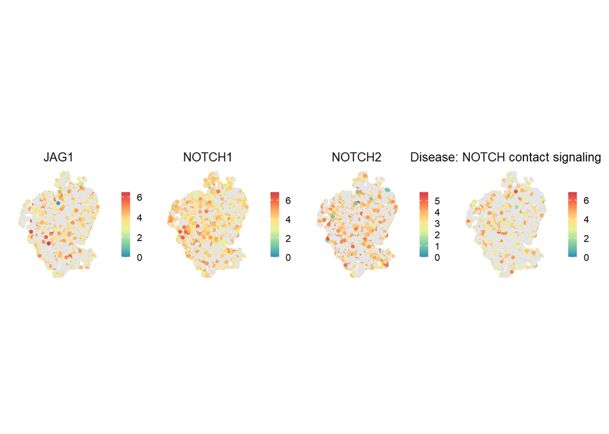

```r
p_notch_disease
```

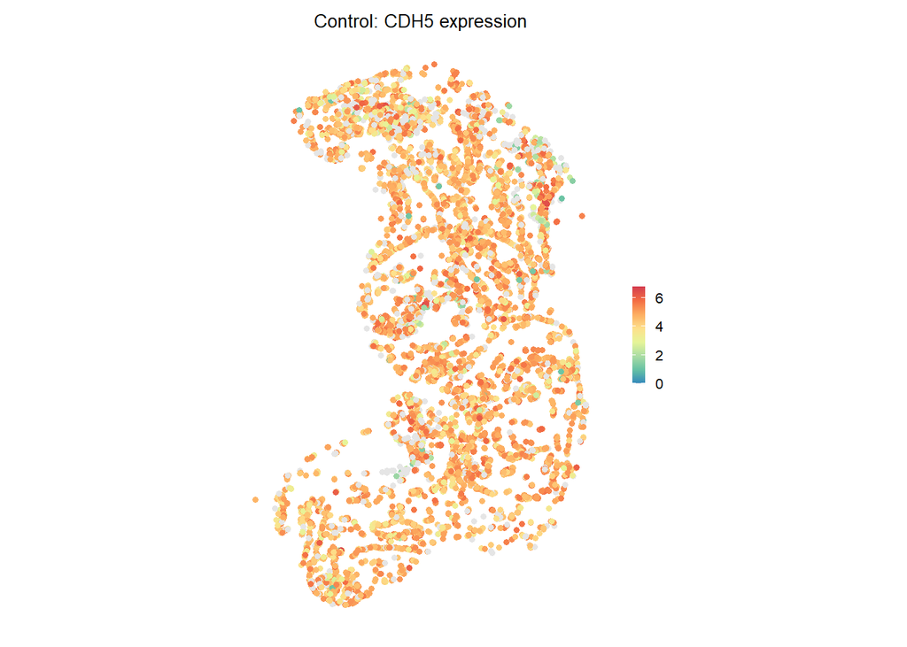

```r
pathway.show <- "CDH5"

# Control: plot CDH5 gene only
p_cdh5_control <- SpatialCellChat::spatialFeaturePlot(
  object.list.contact[[1]],
  features = "CDH5",
  do.group = FALSE,
  do.binary = FALSE,
  color.heatmap = "Spectral",
  point.size = 1.3
) +
  ggtitle("Control: CDH5 expression")

# Disease: plot CDH5 gene only
p_cdh5_disease <- SpatialCellChat::spatialFeaturePlot(
  object.list.contact[[2]],
  features = "CDH5",
  do.group = FALSE,
  do.binary = FALSE,
  color.heatmap = "Spectral",
  point.size = 1.3
) +
  ggtitle("Disease: CDH5 signalling")

p_cdh5_control
```

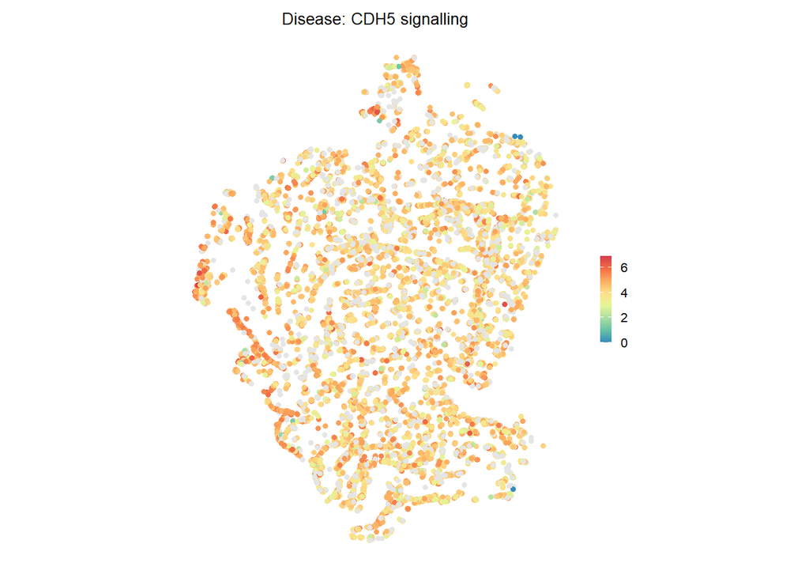

```r
p_cdh5_disease
```